# Simulation study: Correlation between power and sample size

Yan Shen

12/02/2019

# I. Introduction

A common research objective is to demonstrate that a strong correlation exist between two measurements, so we can use the more convenient measurement to infer the other measurement.

In this blog post, assume that we want to prove that two measurements A and B are highly associated when the correlation is greater than 0.8.

We investigate relationship between **power** (the probability that the null Hypothesis is correctly rejected), **true population correlation**, and **sample size N**.

# II. Setup

Assume that the underlying distribution is two-variable normal distribution.

We let the **sample size be 25, 50, 75, 100**; let the **population range from 0.8 to 0.96**, and we run the simulation **5000** times for each scenario. For each case, we generate a one-sided confidence interval and check if it’s larger than our null correlation value (0.8). If true, we say this is a “success”. Then we determine the power by computing the averge number of successes.

# III. Calculation

First, we set the variables (sample size and population size), and the constant parameters.

```r
set.seed(20394)
suppressPackageStartupMessages(require(mvtnorm))
N <- seq(25, 100, 25)
rho <- seq(0.8, 0.96, 0.02)
null_correlation <- 0.8
R <- 5000
```

```r
power_curve <- function(N, rho){
  n <- length(N)
  m <- length(rho)

  curves <- array(rep(NA, n*m), c(n, m))
  for (k in 1:n){
    for (j in 1:m){
      # covariance matrix and means
      sigma <- array(c(1, rho[j], rho[j], 1), c(2, 2))
      mu <- c(0,0)

      detect <- rep(NA, R)
      for(i in 1:R){
        data <- rmvnorm(N[k], mean = mu, sigma = sigma)
        results <- cor.test(x = data[, 1], y = data[,2], alternative = "greater")
        detect[i] <- results$conf.int[1] > null_correlation
      }
      curves[k, j] <- mean(detect)
    }
  }
  curves
}
```

```r
result <- power_curve(N, rho)
```

Plot the result:

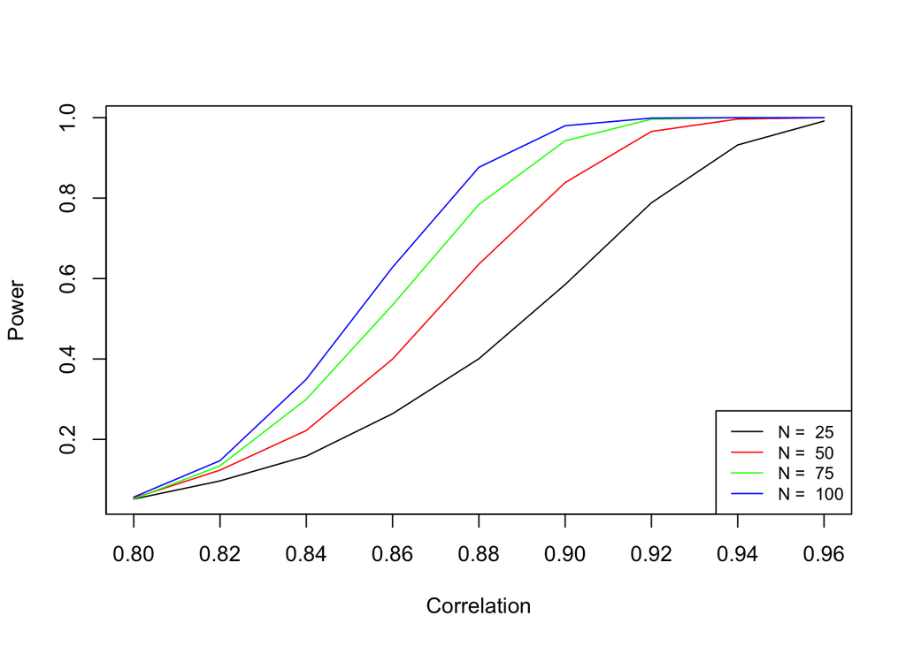

```r
colors <- c("black", "red", "green", "blue")
plot(rho, result[1,], type = "l", col = colors[1],
     xaxp = c(0.80, 0.96, 8), yaxp = c(0, 1, 5),
     xlab = "Correlation", ylab = "Power")
for(i in c(2,3,4)){
  lines(rho, result[i,], col = colors[i])
}
legend("bottomright", legend= paste("N = ", N),
       col=colors, lty = 1, cex=0.8)
```

# IV. Result and Intepretation

For each sample size N, the larger the true underlying population correlation is, the bigger the power is. In other words, the more the two measurements are correlated in reality, the bigger chance we can correctly conclude that they are related.

For each true correlation, the larger the sample size result in larger power. This is because larger population result in tighter confidence interval, so it’s more likely to capture the true underlying correlation (which is > 0.8 in our assumption).